# Untitled

Akira Terui

2023-01-10

## Aim

Develop a statistical tool to identify communities that are sensitive to priority effects. Some ideal features we want in this approach - (1) does not require a huge sample size; (2) robust to species richness in the community.

## Approach

#### Full community modeling

The first approach I tried is the development of time-series community models – If the community is truly neutral, the model with neutral assumption should be selected. Specifically, I developed the following state-space model:

$$N_{i,t+1} = N_{i,t} \exp(r - \sum\alpha_{ij}N_j)$$

When the community is neutral, $\alpha_{ij} = \alpha =1$. This approach might work when the time series is very long in comparison to the number of species $S$. This is because, although a neutral model requires only one parameter for competition coefficients ($\alpha_{ij}$), full model requires $S$ parameters. As a result, the comparison between the two models work only when time series is insanely long (> 100?). This is not a feasible approach.

#### Community-level density dependence

A novel approach is required to reduce the number of parameters. One potential approach I could think of was the community-level density dependence. When the community is neutral, the above model can be reduced to:

$$N_{i,t+1} = N_{i,t} \exp(r - \alpha \sum N_j) = N_{i,t} \exp(r - \alpha
N_T)$$

where $N_T$ is the community density. Theoretically, if the community is neutral, the intraspecific competition must equate the community-level density dependence. Specifically, we can compare the coefficient of the following statistical models:

$$\begin{aligned}
\log r_{i,t} &= r_i - \alpha_i N_i\\
\log r_{i,t} &= r_0 - \alpha N_T
\end{aligned}$$

If neutral, the ratio $\alpha_i / \alpha$ should approach a value of one. However, this approach did not work because of the nature of time-series analysis. When evaluating the intraspecific density-dependence, the effect of interspecific interactions was absorbed into the estimate of $\alpha_i$, resulting in a serious bias in the ratio of $\alpha_i / \alpha$.

#### Scaling law in density dependence

The last approach is derived analytically and most promising so far. This approach will use “frequency dependence” rather than density dependence. Consider a generalized LV model:

$$\frac{1}{N_i}\frac{dN_i}{dt} = r - \beta N_i - \sum_{j \ne i}
\alpha_jN_j + \frac{m}{N_i}$$

where $m$ is the number of immigrants. This equation can be re-written as (assuming $\alpha = \alpha_j$):

$$\frac{1}{N_i}\frac{dN_i}{dt} = r - \beta p_i N_T - \alpha (1 - p_i) N_T
+ \frac{m}{N_T}p_i^{-1}$$

where $p_i$ is the proportion of species $i$ in the community ($N_i / N_T$). Partial derivative with respect to $p_i$:

$$\frac{d}{dp_i}(\frac{1}{N_i} \frac{dN_i}{dt}) = (\alpha - \beta) N_T -
\frac{m}{N_T} p_i^{-2}$$

In an empirical analysis, the above equation is the slope between population growth $\log \frac{N_{t+1}}{N_t}$ and frequency $p_i$. For example, $\gamma$ in the following formula: $\log \frac{N_{t+1}}{N_t} \sim \delta + \gamma p_i$.

When the community is neutral ($\alpha = \beta$), an interesting expectation will emerge:

$$\frac{d}{dp_i}(\frac{1}{N_i} \frac{dN_i}{dt}) = \gamma = -\frac{m}{N_T}
p_i^{-2}$$

Thus, $-\gamma$ will follow a power law of $p_i$ when it is a neutral with the scaling exponent of $-2$.

## Simulation

See if scaling law holds true in simulated dataset:

1. No variation in alpha, r, k

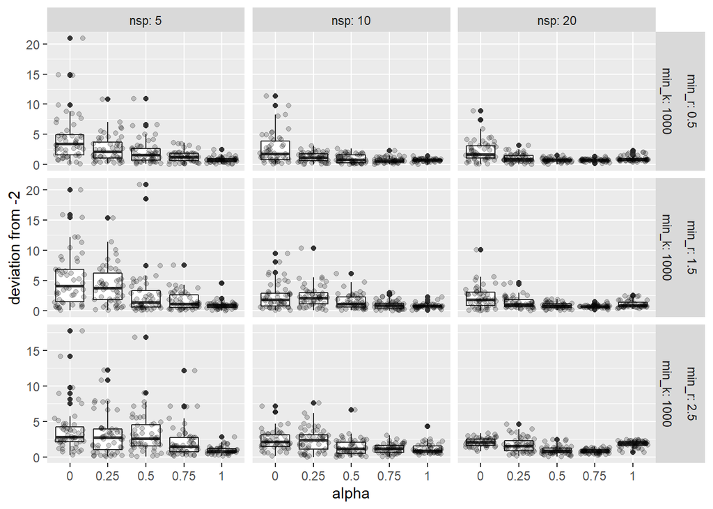

2. No variation in alpha; Variation in r, k

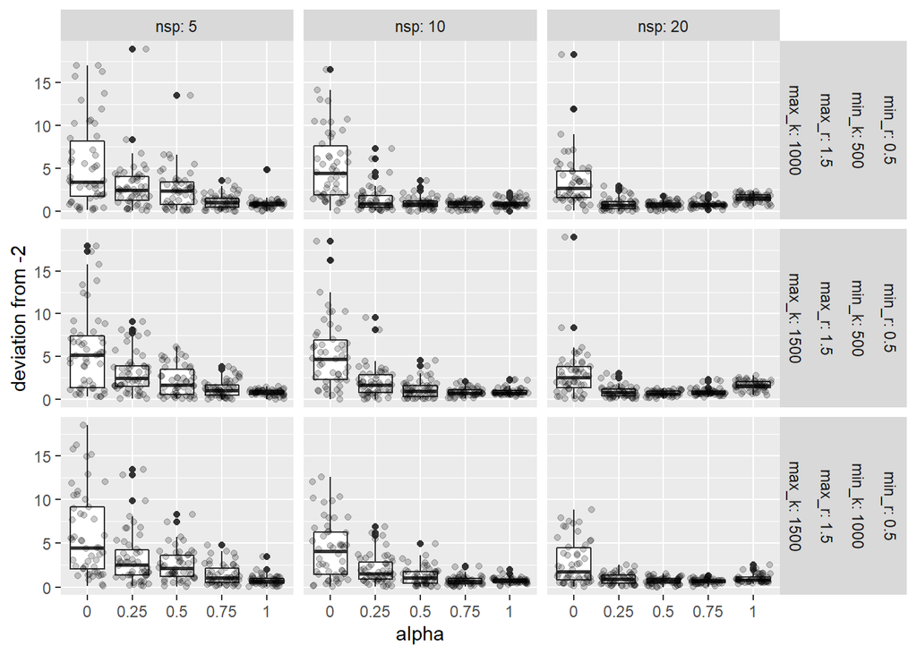

3. Variation in alpha; No variation in r, k

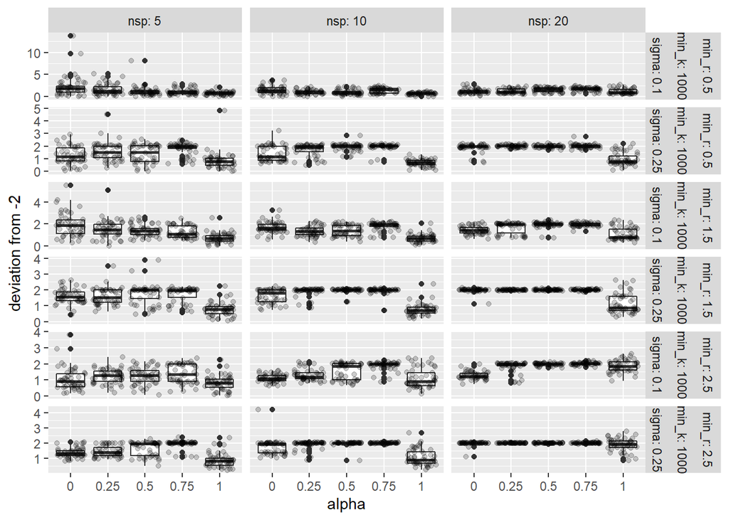

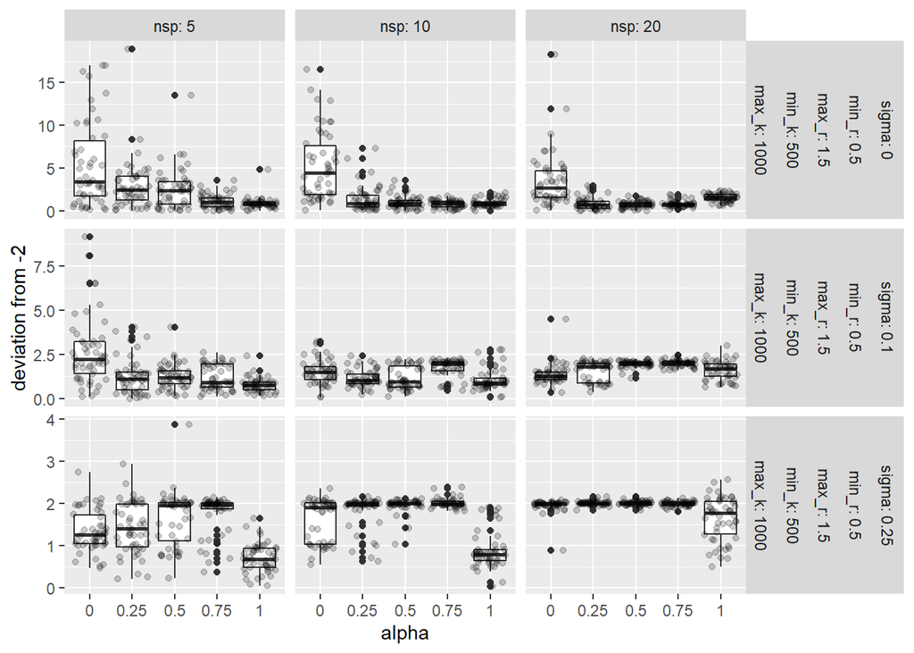